# Exercise 2.16: En halv linje

##### a)

Skisse av systemet:

[figure not shown]

Ladningen i $x'$ er lik $dq = \rho_{l} dx'$.

Vi vet at det elektriske potensialet i et punkt $\vec{r}$ som kommer av en punktladning $Q$ er lik: $V(\vec{r}) = \dfrac{Q}{4\pi \epsilon_0} \dfrac{1}{r}$

Bidraget $dV$ til potensialet i punktet $\vec{r} = (x, 0)$ som kommer av ladningen $dq$ er da:

$$dV = \dfrac{dq}{4 \pi \epsilon_0} \dfrac{1}{R} = \dfrac{\rho_{l} dx'}{4 \pi \epsilon_0} \dfrac{1}{|x-x'|}$$

##### b)

Det totale potensialet i $\vec{r} = (x, 0)$ som kommer av linjeladningen fra $x=-L$ til $x=0$ er da:

\begin{align*} V(x) &= \int_{-L}^{0} \dfrac{\rho_{l} dx'}{4 \pi \epsilon_0} \dfrac{1}{|x-x'|} \,dx' \\[10pt] &= \dfrac{\rho_{l}}{4 \pi \epsilon_0} \int_{-L}^{0} \dfrac{1}{|x-x'|} \,dx' \\[10pt] &= \dfrac{\rho_{l}}{4 \pi \epsilon_0} \int_{-L}^{0} \dfrac{1}{x-x'} \,dx' \qquad \text{(siden x > 0)} \\[10pt] &= \dfrac{\rho_{l}}{4 \pi \epsilon_0} \int_{-L}^{0} \dfrac{1}{-x'+x} \,dx' \\[10pt] &= \dfrac{\rho_{l}}{4 \pi \epsilon_0} \left[-\ln(-x'+x)\right]_{-L}^0 \\[10pt] &= \dfrac{\rho_{l}}{4 \pi \epsilon_0} (-\ln(x) + \ln(L+x)) \\[10pt] &= \dfrac{\rho_{l}}{4 \pi \epsilon_0} \ln(\dfrac{L+x}{x}) \end{align*}

Plotter potensialet:

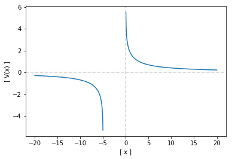

```python
from tkinter.ttk import Style
import numpy as np
import matplotlib.pyplot as plt
L = 5
x = np.linspace(-L*4, L*4, 1000)
V = np.log((L+x)/x)
plt.plot(x, V)
plt.xlabel("[ x ]")
plt.ylabel("[ V(x) ]")
plt.axhline(0,color='lightgrey', ls='--') # x = 0
plt.axvline(0,color='lightgrey', ls='--') # y = 0
plt.show()
```

Fra plottet ser vi at potensialet $V(x)$ går mot null når x går mot $\pm \infty$ og at det går mot utendelig ved x=-L og x=0. Dette virker rimelig.

##### c)

Det elektriske feltet langs x-aksen er da deriverte av potensialet:

\begin{align*} E_x(x, 0) &= -\dfrac{dV}{dx} \\[10pt] &= -\dfrac{\rho_{l}}{4 \pi \epsilon_0} \dfrac{d}{dx}(\ln(\dfrac{L+x}{x})) \\[10pt] &= -\dfrac{\rho_{l}}{4 \pi \epsilon_0} \dfrac{d}{dx}(\ln(L+x) - \ln(x)) \\[10pt] &= -\dfrac{\rho_{l}}{4 \pi \epsilon_0} (\dfrac{1}{L+x} - \dfrac{1}{x}) \\[10pt] &= -\dfrac{\rho_{l}}{4 \pi \epsilon_0} \dfrac{x -(L + x)}{x(L+x)} \\[10pt] &= \dfrac{\rho_{l}}{4 \pi \epsilon_0} \dfrac{L}{x(L+x)} \\[10pt] \end{align*}

Vi ser at når x går mot null, så blir E-feltet uendelig stort. Og når x blir større, så blir E-feltet mindre. Dette virker rimelig.

##### d)

Vi kan ikke bruke potensialet $V(x)$ til å finne $E_y(x, 0)$ ettersom $V(x)$ kun er definert langs x-aksen.  
Hvis vi ønsker å finne $E_y(x, 0)$ så må vi finne $V(x, y)$, som er definert langs x-aksen og y-aksen.